# ToothGrowth Explorer

October 28, 2026

## The question and the data

### Three doses × two supplement methods

The experiment measured tooth length after vitamin C was delivered as **orange juice (OJ)** or **ascorbic acid (VC)**, at **0.5, 1, or 2 mg/day**.

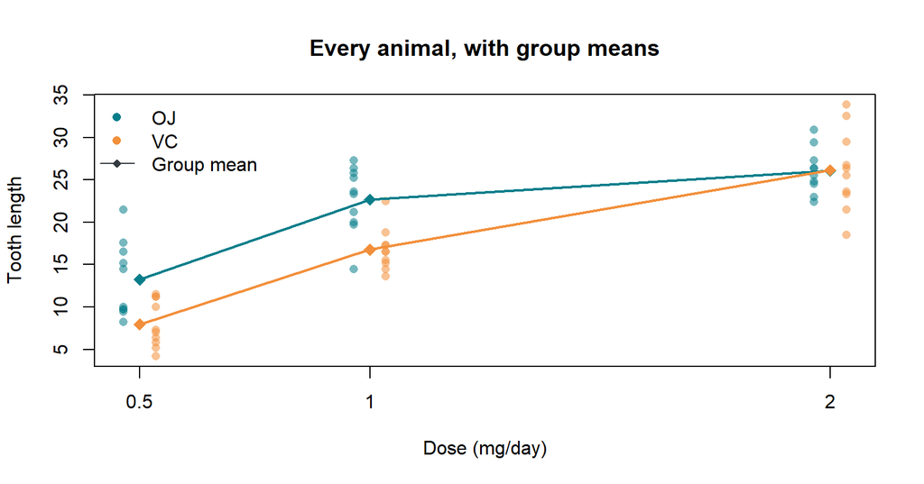

**App purpose:** make dose-specific measurements and a cautious mean comparison easy to inspect without writing R code.

## Inside the Shiny app

### Two controls update the whole view

- Choose a supplement with radio buttons.
- Choose a dose from the three tested amounts.
- The server reacts to both inputs: the summary, confidence interval, test, and chart update together.
- Point the cursor at a dot to inspect an animal; the app’s left panel explains every step.

**The question stays simple:** what did these 10 animals show at this dose, and how uncertain is the average comparison?

## What the app calculates

### Pick one group; get a mean and an interval

The user selects a supplement and dose. The app calculates the selected group’s **sample mean** and **95% t confidence interval**, then compares it with the other supplement at that dose using a **Welch two-sample t-test**.

```r
example <- subset(tg, dose == 0.5)
oj <- subset(example, supp == "OJ")$len
vc <- subset(example, supp == "VC")$len
test <- t.test(oj, vc)
cat(sprintf("0.5 mg/day: OJ mean %.2f; VC mean %.2f\n", mean(oj), mean(vc)))
```

```
## 0.5 mg/day: OJ mean 13.23; VC mean 7.98
```

```r
cat(sprintf("OJ - VC 95%% CI: %.2f to %.2f; p = %.4f", test$conf.int[1], test$conf.int[2], test$p.value))
```

```
## OJ - VC 95% CI: 1.72 to 8.78; p = 0.0064
```

The interactive chart shows each animal and the two group-mean curves. Hover details help users connect summary values to the observations.

## A simple, transparent workflow

### Choose · inspect · interpret

1. Select **OJ** or **VC**.
2. Choose a dose: **0.5**, **1**, or **2 mg/day**.
3. Read the mean and 95% interval; compare the other supplement at the same dose.
4. Hover over chart points to inspect individual measurements.

**Built-in help:** the app contains usage instructions, definitions, and assumptions in its left-hand panel.

**Limits:** each group has 10 animals. The intervals assume independent observations and approximately normal measurements within groups. Results describe this experiment; they do not prove effects for all animals or doses.

**Run it:** `shiny::runApp("toothgrowth_shiny_app")`  
**Data:** `datasets::ToothGrowth` (included with R)